# 210722 Today I Learned

# Table of Contents

## 논문 리딩

- A Recurrent Latent Variable Model for Sequential Data

  읽고 구현 해봐야 함

### 추천 받은 논문들

#### Understanding Failures in Out-of-Distribution Detection with Deep Generative Models

- deep generative model로 out-of-distribution detection을 할 때 생길 수 있는 문제점에 대해서 이야기하는 것이 주된 내용
- 간단하게나마 어떻게 하면 피할 수 있을지 discussion을 하고 있으며 생성모델에 대해서 좀 더 이해하기 위해서도 좋은 논문인 것 같음

#### Lipschitz Continuous Autoencoders in Application to Anomaly Detection

- AISTATS 2020 페이퍼, 이상치 탐지하는 과정에서 reconstruction Loss를 이상치 score로 사용하는 것에 대한 정당성을 리뷰
- 기본적으로 Wasserstein 오토인코더와 VAE의 차이첨을 설명하고 어떻게 이상치 탐지를 위한 admissible한 오토인코더를 만드는지에 대해서 설명

#### Autoencoding Under Normalization Constraints

- AE를 outlier detection 용으로 쓰기 위해서 outlier를 의도적으로 좀 더 학습하지 못하도록 normalize constraint를 추가한 모델
- https://www.youtube.com/watch?v=ra6usGKnPGk

```python
from IPython.display import YouTubeVideo

YouTubeVideo('ra6usGKnPGk', width=600, height=300)
```

[video not shown]

내일 읽자....

## ICML Workshop 내용 확인

[ICML 2021 Workshop on Representation Learning for Finance and e-Commerce Applications](https://sites.google.com/view/rlfeca2021/home?authuser=0)

Call for Papers We invite short papers on all aspects of representation learning related to financial services and e-commerce.

Topics include (but not limited to) the following:

```
Representation learning on financial graphs

Representation learning in language models

Representation learning on tabular datasets

Event sequence representations

Multi-modal fusion for combining disparate data types

Dynamics of representations over time

Representation learning for anomaly detection

Gleaning behavioral, social, and economic insights from representations of financial datasets

Identifying and mitigating bias in representations
```

Applications covered in this workshop will include but not limited to:

```
Finance

E-commerce

Fraud detection

Financial planning

Econometric models

Economic forecasting

Recommender Systems

Asset valuation

Financial instrument pricing

Algorithmic trading

Loan underwriting

Portfolio management

Risk management

Customer service

Privacy
```

연구실에서 결제 해놔서 다시보기 할 수 있으니까 재미있는거 확인해보기

## Dive into Deep Learning 공부

- Chapter 3 복습 기본적인 코드 구조 명확히 이해완료
  1. Forward
  2. Loss
  3. Back Propagation
  4. Update Params(Using Optimizer)
- Chapter 4 MLP 공부중

## Pandas-TA 모듈 살펴보기

Github: https://github.com/twopirllc/pandas-ta

- 기술적 분석(TA)모듈은 ta-lib이 유명하긴 한데 윈도우에서는 설치가 쫌 복잡했던 기억이 있음(JAVA로 만들어져 있는 Python Wrapper 였던걸로 기억). ta-lib 없어도 기술 지표나 여러 기능들 사용 가능(일부 기능은 ta-lib 있어야 작동)
- 캔들 차트 모듈은 예전에 mpl-finance에 있던 모듈 이식하였고 기술적 지표를 이용한 전략들을 클래스안에 넣어서 시각화 해주는 기능이 있음

```python
# Used for example Trend Return Long Trend Below
macd_ = ta.macd(closedf)
macdh = macd_[macd_.columns[1]]

Chart(df,
    # style: which mplfinance chart style to use. Added "random" as an option.
    # rpad: how many bars to leave empty on the right of the chart
    style="yahoo", title=ticker, last=recent_bars(df), rpad=10,

    # Overlap Indicators
    linreg=True, midpoint=False, ohlc4=False, archermas=True,

    # Example Indicators with default parameters
    volume=True, rsi=True, clr=False, macd=True, zscore=False, squeeze=False, lazybear=False,

    # Archer OBV and OBV MAs (https://www.tradingview.com/script/Co1ksara-Trade-Archer-On-balance-Volume-Moving-Averages-v1/)
    archerobv=False,

    # Create trends and see their returns
    tsignals=True,
    # Example Trends or create your own. Trend must yield Booleans
    long_trend=ta.sma(closedf,10) > ta.sma(closedf,20), # trend: sma(close,10) > sma(close,20) [Default Example]
#     long_trend=closedf > ta.ema(closedf,5), # trend: close > ema(close,5)
#     long_trend=ta.sma(closedf,10) > ta.ema(closedf,50), # trend: sma(close,10) > ema(close,50)
#     long_trend=ta.increasing(ta.ema(closedf), 10), # trend: increasing(ema, 10)
#     long_trend=macdh > 0, # trend: macd hist > 0
#     long_trend=macd_[macd_.columns[0]] > macd_[macd_.columns[-1]], # trend: macd > macd signal
#     long_trend=ta.increasing(ta.sma(ta.rsi(closedf), 10), 5, asint=False), # trend: rising sma(rsi, 10) for the previous 5 periods
#     long_trend=ta.squeeze(highdf, lowdf, closedf, lazybear=True, detailed=True).SQZ_PINC > 0,
#     long_trend=ta.amat(closedf, 50, 200, mamode="sma").iloc[:,0], # trend: amat(50, 200) long signal using sma
    show_nontrading=False, # Intraday use if needed
    verbose=True, # More detail
)
```

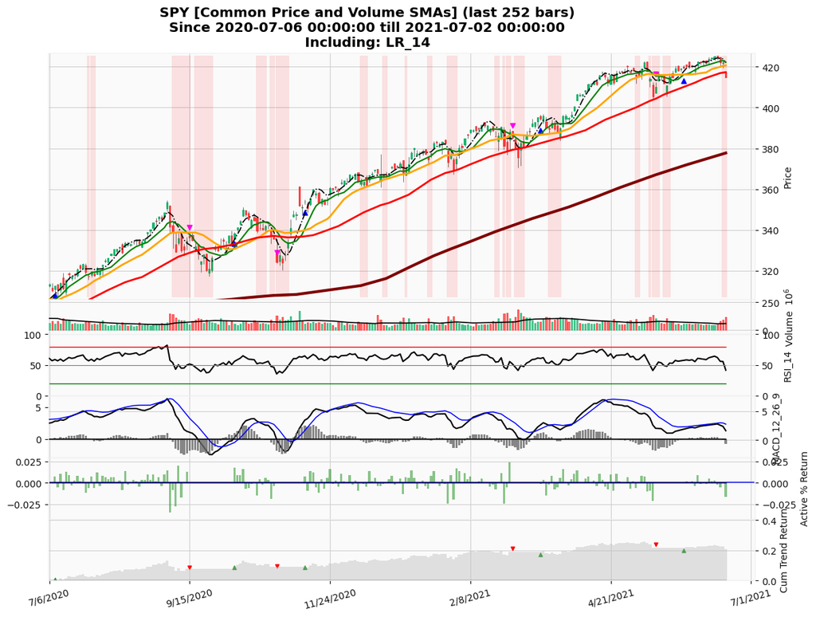